# Feature Engineering on the Cleaned Final Data Set

```python
import numpy as np
import pandas as pd
import matplotlib.pyplot as plt
%matplotlib inline
```

#### Reading the cleaned final dataset

```python
tmc_finaldata = pd.read_csv("tmc_final_data.csv")
```

```python
tmc_finaldata.head()
```

|  | DAY_DT | LOC_IDNT | DBSKU | FULL_PRICE_IND | TOTAL_SALES | TOTAL_UNITS | TOTAL_SALES_PRFT | TOTAL_COST | UNIT_SALES_PRICE | CITY | STATE | STORE_TYPE | POSTAL_CD | STORE_SIZE | DEPARTMENT | CLASS | SUBCLASS | SUBCLASS_NAME | DSUBCLASS |
| --- | --- | --- | --- | --- | --- | --- | --- | --- | --- | --- | --- | --- | --- | --- | --- | --- | --- | --- | --- |
| 0 | 2015-09-26 | 1218 | 466896.0 | 0 | 16.80 | 1.0 | 1.3000 | 15.5000 | 16.80 | COLUMBIA | SC | Lifestyle Center | 29229.0 | 3050.0 | 10.0 | 3.0 | 31.0 | Sub Class 2 | 1031.0 |
| 1 | 2015-08-02 | 1218 | 412445.0 | 0 | 29.99 | 1.0 | 12.9900 | 17.0000 | 29.99 | COLUMBIA | SC | Lifestyle Center | 29229.0 | 3050.0 | 10.0 | 2.0 | 21.0 | Sub Class 2 | 1021.0 |
| 2 | 2015-10-21 | 1218 | 491738.0 | 1 | 44.00 | 1.0 | 28.2500 | 15.7500 | 44.00 | COLUMBIA | SC | Lifestyle Center | 29229.0 | 3050.0 | 10.0 | 5.0 | 50.0 | Sub Class 3 | 1050.0 |
| 3 | 2015-08-02 | 1218 | 414979.0 | 0 | 24.00 | 1.0 | 6.9936 | 17.0064 | 24.00 | COLUMBIA | SC | Lifestyle Center | 29229.0 | 3050.0 | 10.0 | 3.0 | 32.0 | Sub Class 1 | 1032.0 |
| 4 | 2015-07-26 | 1218 | 458372.0 | 1 | 48.00 | 1.0 | 30.0000 | 18.0000 | 48.00 | COLUMBIA | SC | Lifestyle Center | 29229.0 | 3050.0 | 10.0 | 3.0 | 32.0 | Sub Class 1 | 1032.0 |

### Dropping the insignificant Variables and reasons

- 'DEPARTMENT', 'SUBCLASS' are replaced with its equivalent "DSUBCLASS"; 'CLASS','SUBCLASS_NAME' are insignificant
- 'LOC_IDNT', 'POSTAL_CD' is represented with corresponding CITY, STATE, STORE_TYPE and STORE_SIZE, hence Dropping it
- 'TOTAL_SALES_PRFT', 'TOTAL_COST', 'TOTAL_SALES' are replaced with a Derived Column 'UNIT_SALES_PRICE'
- 'CITY' - at this stage of initial modelling we are analysing Statewise rather than Citywise

```python
tmc_finaldata.drop(['DEPARTMENT','CLASS','SUBCLASS_NAME','SUBCLASS','LOC_IDNT','TOTAL_SALES_PRFT','TOTAL_COST',
                    'TOTAL_SALES','POSTAL_CD','CITY'],axis=1,inplace=True)
```

```python
tmc_finaldata.dtypes
```

```
DAY_DT               object
DBSKU               float64
FULL_PRICE_IND        int64
TOTAL_UNITS         float64
UNIT_SALES_PRICE    float64
STATE                object
STORE_TYPE           object
STORE_SIZE          float64
DSUBCLASS           float64
dtype: object
```

#### Downcasting datatypes to reduce the memory usage by the dataframe

```python
tmc_finaldata['DSUBCLASS'] = tmc_finaldata['DSUBCLASS'].astype(np.int16)
tmc_finaldata['STORE_TYPE'] = tmc_finaldata['STORE_TYPE'].astype('category')
tmc_finaldata['STATE'] = tmc_finaldata['STATE'].astype('category')
tmc_finaldata['STORE_SIZE'] = tmc_finaldata['STORE_SIZE'].astype(np.int16)
tmc_finaldata['FULL_PRICE_IND'] = tmc_finaldata['FULL_PRICE_IND'].astype(np.int8)
tmc_finaldata['DBSKU'] = tmc_finaldata['DBSKU'].astype(np.int32)
tmc_finaldata['TOTAL_UNITS'] = tmc_finaldata['TOTAL_UNITS'].astype(np.int16)
tmc_finaldata['DAY_DT'] = pd.to_datetime(tmc_finaldata['DAY_DT'])
```

```python
tmc_finaldata.dtypes
```

```
DAY_DT              datetime64[ns]
DBSKU                        int32
FULL_PRICE_IND                int8
TOTAL_UNITS                  int16
UNIT_SALES_PRICE           float64
STATE                     category
STORE_TYPE                category
STORE_SIZE                   int16
DSUBCLASS                    int16
dtype: object
```

```python
tmc_finaldata.columns = tmc_finaldata.columns.str.title()
```

```python
tmc_selected_group = tmc_finaldata
```

```python
tmc_selected_group.shape
```

```
(12589631, 9)
```

#### Converting the Day_Dt column's transaction Date value to Seasonal representing value for analysing seasonal sales

```python
tmc_selected_group['date'] = tmc_selected_group['Day_Dt']
```

```python
# calculate day of year
tmc_selected_group['doy'] = tmc_selected_group['date'].dt.dayofyear
# Create year
tmc_selected_group['Year'] = tmc_selected_group['date'].dt.year

#to divide by season it's better to use the day of the year instead of the months
spring = range(80, 172)
summer = range(172, 264)
fall = range(264, 355)
# winter = everything else

date = []
for i in tmc_selected_group['doy']:
    if i in spring:
        season = 'spring'
    elif i in summer:
        season = 'summer'
    elif i in fall:
        season = 'fall'
    else:
        season = 'winter'
    date.append(season)
    #add the resulting column to the dataframe (after transforming it as a Series)
tmc_selected_group['season']= pd.Series(date)
```

```python
tmc_selected_group.head()
```

|  | Day_Dt | Dbsku | Full_Price_Ind | Total_Units | Unit_Sales_Price | State | Store_Type | Store_Size | Dsubclass | date | doy | Year | season |
| --- | --- | --- | --- | --- | --- | --- | --- | --- | --- | --- | --- | --- | --- |
| 0 | 2015-09-26 | 466896 | 0 | 1 | 16.80 | SC | Lifestyle Center | 3050 | 1031 | 2015-09-26 | 269 | 2015 | fall |
| 1 | 2015-08-02 | 412445 | 0 | 1 | 29.99 | SC | Lifestyle Center | 3050 | 1021 | 2015-08-02 | 214 | 2015 | summer |
| 2 | 2015-10-21 | 491738 | 1 | 1 | 44.00 | SC | Lifestyle Center | 3050 | 1050 | 2015-10-21 | 294 | 2015 | fall |
| 3 | 2015-08-02 | 414979 | 0 | 1 | 24.00 | SC | Lifestyle Center | 3050 | 1032 | 2015-08-02 | 214 | 2015 | summer |
| 4 | 2015-07-26 | 458372 | 1 | 1 | 48.00 | SC | Lifestyle Center | 3050 | 1032 | 2015-07-26 | 207 | 2015 | summer |

Dropping the Day_Dt column and other intermediate columns

```python
tmc_selected_group.drop(['Day_Dt','date','Year','doy'],axis=1,inplace=True)
```

Converting the season variable into Category type

```python
tmc_selected_group['season'] = tmc_selected_group['season'].astype('category')
```

#### checking for the no. of transactions with Total_Units != 1 and ==1

```python
tmc_selected_group[tmc_selected_group['Total_Units']!=1].count()
```

```
Dbsku               611814
Full_Price_Ind      611814
Total_Units         611814
Unit_Sales_Price    611814
State               611814
Store_Type          611814
Store_Size          611814
Dsubclass           611814
season              611814
dtype: int64
```

```python
tmc_selected_group[tmc_selected_group['Total_Units']==1].count()
```

```
Dbsku               11977817
Full_Price_Ind      11977817
Total_Units         11977817
Unit_Sales_Price    11977817
State               11977817
Store_Type          11977817
Store_Size          11977817
Dsubclass           11977817
season              11977817
dtype: int64
```

#### Realized that there are majority of transactions with Total_Units =1

#### Converting the Units_Sales_Price into Bins (price binning )

```python
tmc_selected_group['Unit_Sales_Price'].max()
```

```
150.0
```

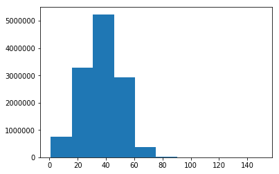

```python
plt.hist(tmc_selected_group['Unit_Sales_Price'])
```

#### as per the above plot we can see that the price distribution seems to be normal and majority of it lies in b/w 20 - 60

considering an example of subclass = Dsubclass_105

```python
tmc_1050 = tmc_selected_group[(tmc_selected_group['Total_Units']==1) & (tmc_selected_group['Dsubclass']==1050)]
```

```python
tmc_1050_price = tmc_1050[['Unit_Sales_Price','Total_Units']]
```

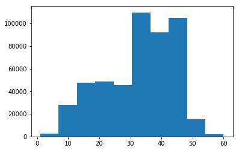

```python
plt.hist(tmc_1050_price['Unit_Sales_Price'])
```

```python
bins = [0, 5, 10, 15, 20, 25, 30, 35, 40, 45, 50, 55, 60]
labels = ['0-5','5-10','10-15','15-20','20-25','25-30','30-35','35-40','40-45','45-50','50-55','55-60']
tmc_1050_price['binned'] = pd.cut(tmc_1050_price['Unit_Sales_Price'], bins=bins, labels=labels)
tmc_1050_price.head()
```

[output not shown]

|  | Unit_Sales_Price | Total_Units | binned |
| --- | --- | --- | --- |
| 2 | 44.0 | 1 | 40-45 |
| 15 | 16.0 | 1 | 15-20 |
| 58 | 20.0 | 1 | 15-20 |
| 71 | 20.0 | 1 | 15-20 |
| 95 | 50.0 | 1 | 45-50 |

#### In the similar way we will apply the Price Binning for all the transactions of the dataset

```python
print(tmc_selected_group['Unit_Sales_Price'].max())
print(tmc_selected_group['Unit_Sales_Price'].min())
```

```
150.0
1.0
```

#### since the overall Unit_Sales_Price ranges from 1.0 to 150.0, creating bins 50 bins where each bin_size =3

- i.e., price_bins = 0-3, 4-6, 7-9, 10-12 ........

```python
price_bins = np.arange(0,153,3)
price_bins = price_bins.tolist()
print(price_bins)
```

```
[0, 3, 6, 9, 12, 15, 18, 21, 24, 27, 30, 33, 36, 39, 42, 45, 48, 51, 54, 57, 60, 63, 66, 69, 72, 75, 78, 81, 84, 87, 90, 93, 96, 99, 102, 105, 108, 111, 114, 117, 120, 123, 126, 129, 132, 135, 138, 141, 144, 147, 150]
```

```python
price_labels = ['0-3','4-6','7-9','10-12','13-15','16-18','19-21','22-24','25-27','28-30','31-33','34-36','37-39','40-42',
                '43-45','46-48','49-51','52-54','55-57','58-60','61-63','64-66','67-69','70-72','73-75','76-78','79-81',
                '82-84','85-87','88-90','91-93','94-96','97-99','100-102','103-105','106-108','109-111','112-114','115-117',
                '118-120','121-123','124-126','127-129','130-132','133-135','136-138','139-141','142-144','145-147','148,150']
```

```python
tmc_selected_group['Unit_Sales_Price_Range'] = pd.cut(tmc_selected_group['Unit_Sales_Price'],
                                                      bins=price_bins, labels=price_labels)
```

```python
tmc_selected_group.head()
```

|  | Dbsku | Full_Price_Ind | Total_Units | Unit_Sales_Price | State | Store_Type | Store_Size | Dsubclass | season | Unit_Sales_Price_Range |
| --- | --- | --- | --- | --- | --- | --- | --- | --- | --- | --- |
| 0 | 466896 | 0 | 1 | 16.80 | SC | Lifestyle Center | 3050 | 1031 | fall | 16-18 |
| 1 | 412445 | 0 | 1 | 29.99 | SC | Lifestyle Center | 3050 | 1021 | summer | 28-30 |
| 2 | 491738 | 1 | 1 | 44.00 | SC | Lifestyle Center | 3050 | 1050 | fall | 43-45 |
| 3 | 414979 | 0 | 1 | 24.00 | SC | Lifestyle Center | 3050 | 1032 | summer | 22-24 |
| 4 | 458372 | 1 | 1 | 48.00 | SC | Lifestyle Center | 3050 | 1032 | summer | 46-48 |

#### Since we got the Unit_Sales_Price_Range for the Unit_Sales_Price of each tarnsaction, now we can drop Unit_Sales_Price

```python
tmc_selected_group = tmc_selected_group.drop('Unit_Sales_Price',axis=1)
```

```python
tmc_selected_group.head()
```

|  | Dbsku | Full_Price_Ind | Total_Units | State | Store_Type | Store_Size | Dsubclass | season | Unit_Sales_Price_Range |
| --- | --- | --- | --- | --- | --- | --- | --- | --- | --- |
| 0 | 466896 | 0 | 1 | SC | Lifestyle Center | 3050 | 1031 | fall | 16-18 |
| 1 | 412445 | 0 | 1 | SC | Lifestyle Center | 3050 | 1021 | summer | 28-30 |
| 2 | 491738 | 1 | 1 | SC | Lifestyle Center | 3050 | 1050 | fall | 43-45 |
| 3 | 414979 | 0 | 1 | SC | Lifestyle Center | 3050 | 1032 | summer | 22-24 |
| 4 | 458372 | 1 | 1 | SC | Lifestyle Center | 3050 | 1032 | summer | 46-48 |

```python
tmc_selected_group.dtypes
```

```
Dbsku                        int32
Full_Price_Ind                int8
Total_Units                  int16
State                     category
Store_Type                category
Store_Size                   int16
Dsubclass                    int16
season                    category
Unit_Sales_Price_Range    category
dtype: object
```

#### In order not to have duplicates of similar type of transactions, grouping the data based on all necessary columns by summing up the Total_Units Sold

```python
tmc_group = tmc_selected_group.groupby(['Dbsku','Dsubclass','Store_Type','Store_Size','Unit_Sales_Price_Range','State','season','Full_Price_Ind'])['Total_Units'].sum().reset_index()
```

```python
tmc_group.shape
```

```
(8089829, 9)
```

#### If the above Group is formed by including Store_Size, the total no. of transactions = 8089829

#### If the above Group is formed by excluding Store_Size, the total no. of transactions are reduced to 4156384 as below

```python
tmc_selected_group = tmc_selected_group.drop(['Store_Size'],axis=1)
```

```python
tmc_group = tmc_selected_group.groupby(['Dbsku','Dsubclass','Store_Type','Unit_Sales_Price_Range','State','season','Full_Price_Ind'])['Total_Units'].sum().reset_index()
```

```python
tmc_group.shape
```

```
(4156384, 8)
```

This shows that "Store_size" adds a lot of variation to the data and by removing it groups the Data into a feasible set

```python
tmc_group.head()
```

|  | Dbsku | Dsubclass | Store_Type | Unit_Sales_Price_Range | State | season | Full_Price_Ind | Total_Units |
| --- | --- | --- | --- | --- | --- | --- | --- | --- |
| 0 | 100313 | 1021 | Strip Store | 13-15 | KY | spring | 0 | 1 |
| 1 | 100503 | 1040 | Mega Outlet Mall | 7-9 | NC | fall | 0 | 1 |
| 2 | 100503 | 1040 | Mega Outlet Mall | 16-18 | NC | summer | 0 | 1 |
| 3 | 100503 | 1040 | Outlet Strip | 16-18 | TX | summer | 0 | 1 |
| 4 | 100503 | 1040 | Outlet Strip | 19-21 | DE | summer | 0 | 1 |

```python
tmc_maindata = tmc_group
```

#### Sample explanation of why Grouping has to be made

- Before grouping we will have many Duplicate transactions, for eg: as below

```python
tmc_finaldata[(tmc_finaldata.Dbsku==2999987) & (tmc_finaldata.Dsubclass==1252)
& (tmc_finaldata.Store_Type=='Tourist Outlet Strip') & (tmc_finaldata.State=='AZ') & (tmc_finaldata.Unit_Sales_Price==19.75)]
```

|  | Dbsku | Full_Price_Ind | Total_Units | Unit_Sales_Price | State | Store_Type | Store_Size | Dsubclass | season | Unit_Sales_Price_Range |
| --- | --- | --- | --- | --- | --- | --- | --- | --- | --- | --- |
| 83742 | 2999987 | 0 | 1 | 19.75 | AZ | Tourist Outlet Strip | 2866 | 1252 | summer | 19-21 |
| 128413 | 2999987 | 0 | 1 | 19.75 | AZ | Tourist Outlet Strip | 2866 | 1252 | fall | 19-21 |
| 287119 | 2999987 | 0 | 1 | 19.75 | AZ | Tourist Outlet Strip | 2920 | 1252 | fall | 19-21 |
| 491040 | 2999987 | 0 | 1 | 19.75 | AZ | Tourist Outlet Strip | 2920 | 1252 | summer | 19-21 |
| 531377 | 2999987 | 0 | 1 | 19.75 | AZ | Tourist Outlet Strip | 2920 | 1252 | fall | 19-21 |
| 613796 | 2999987 | 0 | 1 | 19.75 | AZ | Tourist Outlet Strip | 2920 | 1252 | summer | 19-21 |
| 766893 | 2999987 | 0 | 1 | 19.75 | AZ | Tourist Outlet Strip | 2920 | 1252 | fall | 19-21 |
| 804323 | 2999987 | 0 | 1 | 19.75 | AZ | Tourist Outlet Strip | 2920 | 1252 | summer | 19-21 |
| 995749 | 2999987 | 0 | 1 | 19.75 | AZ | Tourist Outlet Strip | 2920 | 1252 | fall | 19-21 |

- After grouping, the Duplicate transactions are combined on Total_Units Level

```python
tmc_group[(tmc_group.Dbsku==2999987) & (tmc_group.Dsubclass==1252)
& (tmc_group.Store_Type=='Tourist Outlet Strip') & (tmc_group.State=='AZ') & (tmc_group.Unit_Sales_Price_Range=='19-21')]
```

|  | Dbsku | Dsubclass | Store_Type | Unit_Sales_Price_Range | State | season | Full_Price_Ind | Total_Units |
| --- | --- | --- | --- | --- | --- | --- | --- | --- |
| 4156378 | 2999987 | 1252 | Tourist Outlet Strip | 19-21 | AZ | fall | 0 | 5 |
| 4156379 | 2999987 | 1252 | Tourist Outlet Strip | 19-21 | AZ | summer | 0 | 4 |

```python
tmc_maindata.dtypes
```

```
Dbsku                        int64
Dsubclass                    int64
Store_Type                category
Unit_Sales_Price_Range    category
State                     category
season                    category
Full_Price_Ind               int64
Total_Units                  int16
dtype: object
```

```python
tmc_maindata['Dsubclass'] = tmc_maindata['Dsubclass'].astype('category')
tmc_maindata['Unit_Sales_Price_Range'] = tmc_maindata['Unit_Sales_Price_Range'].astype('category')
tmc_maindata['State'] = tmc_maindata['State'].astype('category')
tmc_maindata['Store_Type'] = tmc_maindata['Store_Type'].astype('category')
tmc_maindata['season'] = tmc_maindata['season'].astype('category')
```

#### Performing Binary encoding for State, Unit_Sales_Price_Range, Dsubclass

```python
import category_encoders as ce
```

```python
bince = ce.BinaryEncoder(verbose=1)
state_encoding = tmc_maindata[['State']]
state_bincode = bince.fit_transform(state_encoding['State'])
tmc_maindata = pd.concat([tmc_maindata,state_bincode], axis=1)
```

```python
bince = ce.BinaryEncoder(verbose=1)
price_encoding = tmc_maindata[['Unit_Sales_Price_Range']]
price_bincode = bince.fit_transform(price_encoding['Unit_Sales_Price_Range'])
tmc_maindata = pd.concat([tmc_maindata,price_bincode], axis=1)
```

```python
bince = ce.BinaryEncoder(verbose=1)
Dsubclass_encoding = tmc_maindata[['Dsubclass']]
Dsubclass_encoding['Dsubclass'] = 'DC'+Dsubclass_encoding['Dsubclass'].astype(str)
Dsubclass_bincode = bince.fit_transform(Dsubclass_encoding['Dsubclass'])
tmc_maindata = pd.concat([tmc_maindata,Dsubclass_bincode], axis=1)
```

[output not shown]

Dropping the State, Unit_Sales_Price_Range, Dsubclass columns after creating respective Binary encoders

```python
tmc_maindata.drop(['State','Unit_Sales_Price_Range','Dsubclass'], axis=1, inplace=True)
```

```python
tmc_maindata.head()
```

|  | Dbsku | Store_Type | season | Full_Price_Ind | Total_Units | State_0 | State_1 | State_2 | State_3 | State_4 | ... | Unit_Sales_Price_Range_3 | Unit_Sales_Price_Range_4 | Unit_Sales_Price_Range_5 | Unit_Sales_Price_Range_6 | Dsubclass_0 | Dsubclass_1 | Dsubclass_2 | Dsubclass_3 | Dsubclass_4 | Dsubclass_5 |
| --- | --- | --- | --- | --- | --- | --- | --- | --- | --- | --- | --- | --- | --- | --- | --- | --- | --- | --- | --- | --- | --- |
| 0 | 100313 | Strip Store | spring | 0 | 1 | 0 | 0 | 0 | 0 | 0 | ... | 0 | 0 | 0 | 1 | 0 | 0 | 0 | 0 | 0 | 1 |
| 1 | 100503 | Mega Outlet Mall | fall | 0 | 1 | 0 | 0 | 0 | 0 | 0 | ... | 0 | 0 | 1 | 0 | 0 | 0 | 0 | 0 | 1 | 0 |
| 2 | 100503 | Mega Outlet Mall | summer | 0 | 1 | 0 | 0 | 0 | 0 | 0 | ... | 0 | 0 | 1 | 1 | 0 | 0 | 0 | 0 | 1 | 0 |
| 3 | 100503 | Outlet Strip | summer | 0 | 1 | 0 | 0 | 0 | 0 | 0 | ... | 0 | 0 | 1 | 1 | 0 | 0 | 0 | 0 | 1 | 0 |
| 4 | 100503 | Outlet Strip | summer | 0 | 1 | 0 | 0 | 0 | 0 | 1 | ... | 0 | 1 | 0 | 0 | 0 | 0 | 0 | 0 | 1 | 0 |

5 rows × 25 columns

#### Creating Dummies for Store_Type, season

```python
tmc_maindata = pd.get_dummies(tmc_maindata, columns= ['Store_Type', 'season'])
```

```python
tmc_maindata.head()
```

|  | Dbsku | Full_Price_Ind | Total_Units | State_0 | State_1 | State_2 | State_3 | State_4 | State_5 | State_6 | ... | Store_Type_Outlet Strip | Store_Type_Power Strip | Store_Type_Regional Mall | Store_Type_Strip Store | Store_Type_Tourist Outlet Mall | Store_Type_Tourist Outlet Strip | season_fall | season_spring | season_summer | season_winter |
| --- | --- | --- | --- | --- | --- | --- | --- | --- | --- | --- | --- | --- | --- | --- | --- | --- | --- | --- | --- | --- | --- |
| 0 | 100313 | 0 | 1 | 0 | 0 | 0 | 0 | 0 | 0 | 1 | ... | 0 | 0 | 0 | 1 | 0 | 0 | 0 | 1 | 0 | 0 |
| 1 | 100503 | 0 | 1 | 0 | 0 | 0 | 0 | 0 | 1 | 0 | ... | 0 | 0 | 0 | 0 | 0 | 0 | 1 | 0 | 0 | 0 |
| 2 | 100503 | 0 | 1 | 0 | 0 | 0 | 0 | 0 | 1 | 0 | ... | 0 | 0 | 0 | 0 | 0 | 0 | 0 | 0 | 1 | 0 |
| 3 | 100503 | 0 | 1 | 0 | 0 | 0 | 0 | 0 | 1 | 1 | ... | 1 | 0 | 0 | 0 | 0 | 0 | 0 | 0 | 1 | 0 |
| 4 | 100503 | 0 | 1 | 0 | 0 | 0 | 0 | 1 | 0 | 0 | ... | 1 | 0 | 0 | 0 | 0 | 0 | 0 | 0 | 1 | 0 |

5 rows × 39 columns

#### By considering Dummy Variable Trap, dropping one dummy variable for each of (Store_Type, Season)

```python
tmc_maindata.drop(['Store_Type_Downtown Store','season_fall'], axis=1, inplace=True)
```

```python
tmc_maindata.shape
```

```
(4156384, 37)
```

```python
tmc_maindata['Full_Price_Ind'] = tmc_maindata['Full_Price_Ind'].astype(np.int8)
```

```python
tmc_maindata.info(memory_usage='deep')
```

```
<class 'pandas.core.frame.DataFrame'>
RangeIndex: 4156384 entries, 0 to 4156383
Data columns (total 37 columns):
Dbsku                              int64
Full_Price_Ind                     int8
Total_Units                        int16
State_0                            int64
State_1                            int64
State_2                            int64
State_3                            int64
State_4                            int64
State_5                            int64
State_6                            int64
Unit_Sales_Price_Range_0           int64
Unit_Sales_Price_Range_1           int64
Unit_Sales_Price_Range_2           int64
Unit_Sales_Price_Range_3           int64
Unit_Sales_Price_Range_4           int64
Unit_Sales_Price_Range_5           int64
Unit_Sales_Price_Range_6           int64
Dsubclass_0                        int64
Dsubclass_1                        int64
Dsubclass_2                        int64
Dsubclass_3                        int64
Dsubclass_4                        int64
Dsubclass_5                        int64
Store_Type_Freestanding Store      uint8
Store_Type_Lifestyle Center        uint8
Store_Type_Mega Outlet Mall        uint8
Store_Type_Mini Mall               uint8
Store_Type_Outlet Mall             uint8
Store_Type_Outlet Strip            uint8
Store_Type_Power Strip             uint8
Store_Type_Regional Mall           uint8
Store_Type_Strip Store             uint8
Store_Type_Tourist Outlet Mall     uint8
Store_Type_Tourist Outlet Strip    uint8
season_spring                      uint8
season_summer                      uint8
season_winter                      uint8
dtypes: int16(1), int64(21), int8(1), uint8(14)
memory usage: 733.3 MB
```

- tmc_maindata --> on which PCA/VIF has to be performed

```python
tmc_maindata.head()
```

|  | Dbsku | Full_Price_Ind | Total_Units | State_0 | State_1 | State_2 | State_3 | State_4 | State_5 | State_6 | ... | Store_Type_Outlet Mall | Store_Type_Outlet Strip | Store_Type_Power Strip | Store_Type_Regional Mall | Store_Type_Strip Store | Store_Type_Tourist Outlet Mall | Store_Type_Tourist Outlet Strip | season_spring | season_summer | season_winter |
| --- | --- | --- | --- | --- | --- | --- | --- | --- | --- | --- | --- | --- | --- | --- | --- | --- | --- | --- | --- | --- | --- |
| 0 | 100313 | 0 | 1 | 0 | 0 | 0 | 0 | 0 | 0 | 1 | ... | 0 | 0 | 0 | 0 | 1 | 0 | 0 | 1 | 0 | 0 |
| 1 | 100503 | 0 | 1 | 0 | 0 | 0 | 0 | 0 | 1 | 0 | ... | 0 | 0 | 0 | 0 | 0 | 0 | 0 | 0 | 0 | 0 |
| 2 | 100503 | 0 | 1 | 0 | 0 | 0 | 0 | 0 | 1 | 0 | ... | 0 | 0 | 0 | 0 | 0 | 0 | 0 | 0 | 1 | 0 |
| 3 | 100503 | 0 | 1 | 0 | 0 | 0 | 0 | 0 | 1 | 1 | ... | 0 | 1 | 0 | 0 | 0 | 0 | 0 | 0 | 1 | 0 |
| 4 | 100503 | 0 | 1 | 0 | 0 | 0 | 0 | 1 | 0 | 0 | ... | 0 | 1 | 0 | 0 | 0 | 0 | 0 | 0 | 1 | 0 |

5 rows × 37 columns

```python
tmctarget =tmc_maindata['Total_Units']
```

```python
tmcdbs =tmc_maindata['Dbsku']
```

```python
import pandas_profiling as pp
pp.ProfileReport(tmc_maindata).to_file(outputfile="./tmc_maindata.html")
```

```python
tmctarget.head()
```

```
0    1
1    1
2    1
3    1
4    1
Name: Total_Units, dtype: int16
```

```python
tmc_maindata.drop(['Dbsku','Total_Units'],axis=1,inplace=True)
```

```python
tmc_maindata_pca = tmc_maindata
```

[output not shown]

```
(4156384, 35)
```

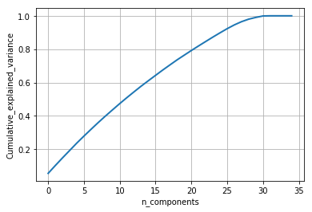

```python
from sklearn.preprocessing import StandardScaler
standardized_data = StandardScaler().fit_transform(tmc_maindata_pca)
print(standardized_data.shape)
sample_data = standardized_data
from sklearn import decomposition
pca = decomposition.PCA()
pca.n_components = 35
pca_data = pca.fit_transform(sample_data)

percentage_var_explained = pca.explained_variance_ / np.sum(pca.explained_variance_);

cum_var_explained = np.cumsum(percentage_var_explained)

plt.figure(1, figsize=(6, 4))

plt.clf()
plt.plot(cum_var_explained, linewidth=2)
plt.axis('tight')
plt.grid()
plt.xlabel('n_components')
plt.ylabel('Cumulative_explained_variance')
plt.show()
```

```python
print('NumPy covariance matrix: \n%s' %np.cov(sample_data.T))
cov_mat = np.cov(sample_data.T)
```

```
NumPy covariance matrix:
[[ 1.00000024  0.          0.01135475 ...,  0.02203302 -0.03011884
  -0.00120056]
 [ 0.          0.          0.         ...,  0.          0.          0.        ]
 [ 0.01135475  0.          1.00000024 ...,  0.00876078  0.0065949
  -0.00793381]
 ...,
 [ 0.02203302  0.          0.00876078 ...,  1.00000024 -0.40833518
  -0.35266536]
 [-0.03011884  0.          0.0065949  ..., -0.40833518  1.00000024
  -0.32071372]
 [-0.00120056  0.         -0.00793381 ..., -0.35266536 -0.32071372
   1.00000024]]
```

```python
#Perform eigendecomposition on covariance matrix
#cov_mat = np.cov(tmc_maindata_pca .T)
eig_vals, eig_vecs = np.linalg.eig(cov_mat)
print('Eigenvectors \n%s' %eig_vecs)
#print('\nEigenvalues \n%s' %eig_vals)
# eigenvectors and eigenvalues for the from the covariance matrix
#scatter_matrix = np.zeros((3,3))
#for i in range(tmc_maindata_pca.shape[1]):
   ## scatter_matrix += (tmc_maindata_pca[:,i].reshape(3,1) - mean_vector).dot((tmc_maindata_pca[:,i].reshape(3,1) - mean_vector).T)
#print('Scatter Matrix:\n', scatter_matrix)
#eig_val_cov, eig_vec_cov = np.linalg.eig(cov_mat)

#for i in range(len(eig_val_sc)):
    #eigvec_sc = eig_vec_sc[:,i].reshape(1,3).T
    #eigvec_cov = eig_vec_cov[:,i].reshape(1,3).T
    #assert eigvec_sc.all() == eigvec_cov.all(), 'Eigenvectors are not identical'

    #print('Eigenvector {}: \n{}'.format(i+1, eigvec_sc))
    #print('Eigenvalue {} from scatter matrix: {}'.format(i+1, eig_val_sc[i]))
    #print('Eigenvalue {} from covariance matrix: {}'.format(i+1, eig_vals[i]))
    #print('Scaling factor: ', eig_val_sc[i]/eig_val_cov[i])
    #print(40 * '-')
```

```
Eigenvectors
[[  2.85823524e-04  -3.35539855e-02  -3.66590713e-02 ...,   0.00000000e+00
    0.00000000e+00   0.00000000e+00]
 [  0.00000000e+00   0.00000000e+00   0.00000000e+00 ...,   1.00000000e+00
    0.00000000e+00   0.00000000e+00]
 [  5.61915176e-04   1.07878423e-02   5.87331466e-03 ...,   0.00000000e+00
    0.00000000e+00   0.00000000e+00]
 ...,
 [ -6.57310029e-04  -1.76057520e-01  -6.01960452e-01 ...,   0.00000000e+00
    0.00000000e+00   0.00000000e+00]
 [ -7.26798634e-04   2.11982560e-01  -5.73295968e-01 ...,   0.00000000e+00
    0.00000000e+00   0.00000000e+00]
 [ -7.42337643e-04  -3.08546903e-02  -5.43894290e-01 ...,   0.00000000e+00
    0.00000000e+00   0.00000000e+00]]
```

```python
# Visually confirm that the list is correctly sorted by decreasing eigenvalues
eig_pairs = [(np.abs(eig_vals[i]), eig_vecs[:,i]) for i in range(len(eig_vals))]
#eig_pairs.sort(key=lambda x: x[0], reverse=True)
print('Eigenvalues in descending order:')
for i in eig_pairs:
    print(i[0])
   # print('Eigenvalue {} from covariance matrix: {}'.format(i+1, eig_pairs[i]))
 #Dump components relations with features:
```

```
Eigenvalues in descending order:
0.0297028539242
1.76249334068
0.275867808248
0.338163283309
0.481613324878
0.61685536009
1.50547329812
1.45944750902
1.42485716183
1.42416508645
1.34596948887
1.31002288978
1.29184279872
0.723849458386
1.24109388253
1.20217208197
1.18964596421
1.14860613662
1.1146407989
1.09330738062
0.796406806489
0.818579768145
0.848642033239
0.853136154706
0.871668102149
0.902663970139
0.900217745961
0.969846190616
0.980035554249
1.03809709815
1.02332143691
1.01760293109
0.0
0.0
0.0
```

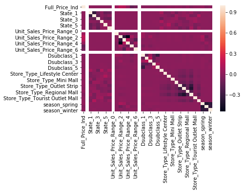

```python
import pandas as pd
import seaborn as sns
import matplotlib.pyplot as plt
from sklearn.preprocessing import LabelEncoder, OneHotEncoder
import warnings
warnings.filterwarnings("ignore")
from sklearn.model_selection import train_test_split
from sklearn.svm import SVC
from sklearn.metrics import confusion_matrix

corr = tmc_maindata_pca.corr()
sns.heatmap(corr)
```

```python
#from patsy import dmatrices
#import statsmodels.api as sm
#from statsmodels.stats.outliers_influence import variance_inflation_factor
```

```python
#%%capture
#gather features
#features = "+".join(tmc_maindata_pca.columns)
# get y and X dataframes based on this regression:
#y, X = dmatrices('Full_Price_Ind ~' + features, tmc_maindata_pca, return_type='dataframe')
```

```python
# For each X, calculate VIF and save in dataframe
#vif = pd.DataFrame()
#vif["VIF Factor"] = [variance_inflation_factor(X.values, i) for i in range(X.shape[1])]
#vif["features"] = X.columns
#vif.round(1)
```

```python
####vif["VIF Factor"] = [variance_inflation_factor(X.values, i) for i in range(X.shape[1])]
#vif["features"] = X.columns
```

```python
#vif.round(1)
```

```python
#pca.components_
from sklearn.decomposition import PCA as sklearnPCA
pca = sklearnPCA(n_components=35)
pca.fit_transform(tmc_maindata_pca)
print(pca.explained_variance_ratio_)
```

[output not shown]

```python
#applying modelling
```

```python
from sklearn.model_selection import train_test_split
import statsmodels.api as sm
from sklearn.linear_model import LinearRegression
X_train, X_test, Y_train, Y_test = train_test_split(tmc_maindata_pca, tmctarget, test_size = 0.3,\
                                                    random_state=101)
```

```python
from sklearn.linear_model import LinearRegression
lin_regres=LinearRegression()
lin_regres.fit(X_train,Y_train)
y_pred=lin_regres.predict(X_test)
```

```python
y_pred
```

```
array([ 3.66245512,  5.6244465 ,  3.40601802, ...,  5.27703988,
        4.49786743,  4.30539426])
```

```python
lin_regres.score(X_train,Y_train)
```

```
0.063356404973321512
```

```python
import statsmodels.api as sm
X_train = sm.add_constant(X_train)
lm_1 = sm.OLS(Y_train, X_train).fit()
lm_1.summary()
```

OLS Regression Results

| Dep. Variable: | Total_Units | R-squared: | 0.063 |
| --- | --- | --- | --- |
| Model: | OLS | Adj. R-squared: | 0.063 |
| Method: | Least Squares | F-statistic: | 6150. |
| Date: | Sun, 05 May 2019 | Prob (F-statistic): | 0.00 |
| Time: | 19:33:56 | Log-Likelihood: | -9.1000e+06 |
| No. Observations: | 2909468 | AIC: | 1.820e+07 |
| Df Residuals: | 2909435 | BIC: | 1.820e+07 |
| Df Model: | 32 |  |  |
| Covariance Type: | nonrobust |  |  |

|  | coef | std err | t | P>\|t\| | [0.025 | 0.975] |
| --- | --- | --- | --- | --- | --- | --- |
| const | 2.3841 | 0.027 | 89.662 | 0.000 | 2.332 | 2.436 |
| Full_Price_Ind | 1.3946 | 0.009 | 148.447 | 0.000 | 1.376 | 1.413 |
| State_0 | -1.016e-15 | 1.01e-16 | -10.013 | 0.000 | -1.21e-15 | -8.17e-16 |
| State_1 | -1.5687 | 0.009 | -167.816 | 0.000 | -1.587 | -1.550 |
| State_2 | -0.6230 | 0.008 | -83.040 | 0.000 | -0.638 | -0.608 |
| State_3 | -0.1489 | 0.007 | -21.530 | 0.000 | -0.163 | -0.135 |
| State_4 | -0.7133 | 0.007 | -106.203 | 0.000 | -0.726 | -0.700 |
| State_5 | -0.6076 | 0.007 | -89.978 | 0.000 | -0.621 | -0.594 |
| State_6 | 0.5886 | 0.007 | 87.393 | 0.000 | 0.575 | 0.602 |
| Unit_Sales_Price_Range_0 | -7.504e-16 | 8.77e-17 | -8.558 | 0.000 | -9.22e-16 | -5.79e-16 |
| Unit_Sales_Price_Range_1 | 0.4461 | 0.082 | 5.416 | 0.000 | 0.285 | 0.608 |
| Unit_Sales_Price_Range_2 | 1.4666 | 0.010 | 153.837 | 0.000 | 1.448 | 1.485 |
| Unit_Sales_Price_Range_3 | 0.6591 | 0.007 | 89.437 | 0.000 | 0.645 | 0.674 |
| Unit_Sales_Price_Range_4 | 0.6309 | 0.008 | 79.970 | 0.000 | 0.615 | 0.646 |
| Unit_Sales_Price_Range_5 | 0.0459 | 0.007 | 6.931 | 0.000 | 0.033 | 0.059 |
| Unit_Sales_Price_Range_6 | 0.1839 | 0.007 | 27.643 | 0.000 | 0.171 | 0.197 |
| Dsubclass_0 | -1.68e-15 | 2.18e-16 | -7.702 | 0.000 | -2.11e-15 | -1.25e-15 |
| Dsubclass_1 | -0.4787 | 0.009 | -55.879 | 0.000 | -0.495 | -0.462 |
| Dsubclass_2 | -0.0900 | 0.007 | -12.564 | 0.000 | -0.104 | -0.076 |
| Dsubclass_3 | -0.2106 | 0.007 | -31.459 | 0.000 | -0.224 | -0.197 |
| Dsubclass_4 | -0.2563 | 0.007 | -37.446 | 0.000 | -0.270 | -0.243 |
| Dsubclass_5 | -0.0626 | 0.007 | -8.800 | 0.000 | -0.077 | -0.049 |
| Store_Type_Freestanding Store | -0.0715 | 0.042 | -1.705 | 0.088 | -0.154 | 0.011 |
| Store_Type_Lifestyle Center | -1.3006 | 0.035 | -36.955 | 0.000 | -1.370 | -1.232 |
| Store_Type_Mega Outlet Mall | -0.8676 | 0.027 | -31.954 | 0.000 | -0.921 | -0.814 |
| Store_Type_Mini Mall | -0.9394 | 0.040 | -23.469 | 0.000 | -1.018 | -0.861 |
| Store_Type_Outlet Mall | -1.0077 | 0.028 | -36.269 | 0.000 | -1.062 | -0.953 |
| Store_Type_Outlet Strip | 0.0326 | 0.023 | 1.439 | 0.150 | -0.012 | 0.077 |
| Store_Type_Power Strip | 1.2497 | 0.022 | 56.364 | 0.000 | 1.206 | 1.293 |
| Store_Type_Regional Mall | -0.6883 | 0.024 | -28.298 | 0.000 | -0.736 | -0.641 |
| Store_Type_Strip Store | 1.4108 | 0.022 | 64.295 | 0.000 | 1.368 | 1.454 |
| Store_Type_Tourist Outlet Mall | -0.9138 | 0.056 | -16.247 | 0.000 | -1.024 | -0.804 |
| Store_Type_Tourist Outlet Strip | -0.8569 | 0.028 | -30.712 | 0.000 | -0.912 | -0.802 |
| season_spring | 0.2104 | 0.009 | 22.581 | 0.000 | 0.192 | 0.229 |
| season_summer | 0.3086 | 0.010 | 32.353 | 0.000 | 0.290 | 0.327 |
| season_winter | -0.1936 | 0.010 | -19.334 | 0.000 | -0.213 | -0.174 |

| Omnibus: | 4688244.426 | Durbin-Watson: | 1.999 |
| --- | --- | --- | --- |
| Prob(Omnibus): | 0.000 | Jarque-Bera (JB): | 9870246978.828 |
| Skew: | 10.155 | Prob(JB): | 0.00 |
| Kurtosis: | 287.616 | Cond. No. | 1.15e+16 |

Warnings:  
[1] Standard Errors assume that the covariance matrix of the errors is correctly specified.  
[2] The smallest eigenvalue is 1.07e-25. This might indicate that there are  
strong multicollinearity problems or that the design matrix is singular.